# Ch2Python基础

Python数据分析基础

## Python程序概述

### 【例2-1】变量赋值示例。

```python
brower, count, addsum = 'Google', 100, 123.45
print(brower, count, addsum)
```

```
Google 100 123.45
```

```python
a=2+3>5+6 or 4+9>4+7
a
```

```
True
```

### 【例2-2】转义字符的使用。

```python
print("python\nprogram")
print("python\"program")
print("python\\program")
print(r"python\nprogram")
```

```
python
program
python"program
python\program
python\nprogram
```

```python
print("python'program")
print('''python
program''')
```

```
python'program
python
program
```

### 【例2-3】将化学分子式翻译为其表示物质对应的英文。

```python
str1,str2='python','world'
print(str1+' '+str2)
print( str1[2:6] )
print( str1[2:5] )
```

```
python world
thon
tho
```

```python
compound = input("请输入化学分子式：")
if compound == "H2O":
    print("water")
elif compound == "NH3":
    print("ammonia")
elif compound == "CH4":
    print("methone")
else:
    print("no exist")
```

```
请输入化学分子式：H2O
water
```

### 【例2-4】求1+2+3+4+5的值。

```python
sum=0
i = 1
while i<6:
    sum = sum+i
    i = i+1
print("sum is %d." %sum)
```

```
sum is 15.
```

### 【例2-5】将下面数组中的奇数变成它的平方，偶数保持不变。

```python
x = [ 1,2,3,4,8,7, 22,33, 88]
print("原数据：",x)
for i in range(len(x)):
    if(x[i] % 2) !=0:   # 判读第 i 个元素是否为奇数
        x[i] = x[i] * x[i]
print("处理后：",x)
```

```
原数据： [1, 2, 3, 4, 8, 7, 22, 33, 88]
处理后： [1, 2, 9, 4, 8, 49, 22, 1089, 88]
```

### 【例2-6】定义函数计算n！。

```python
def fac(n):
    s=1;
    for i in range(2,n+1):
        s=s*i
    return s
n=5
print('%d!=%d'%(n,fac(n)))
```

```
5!=120
```

### 【例2-7】定义一个lambda函数计算多项式1+2*x+y2+z*y的值。

```python
polynominal = lambda x,y,z: 1+2*x+y**2+z*y
polynominal(1,2,3)
```

```
13
```

## 内建数据结构

### 列表

#### 【例2-8】列表中追加元素。

```python
list = ['a', 'b', 'c', 'd']
list.append('Baidu')
print ("追加后的列表 : ", list)
list.insert(1, 'Google')
print ("插入元素后的列表 : ", list)
```

```
追加后的列表 :  ['a', 'b', 'c', 'd', 'Baidu']
插入元素后的列表 :  ['a', 'Google', 'b', 'c', 'd', 'Baidu']
```

#### 【例2-9】返回中第一个指定值的索引。

```python
list = ['a', 'b', 'c', 'd']
print ('b索引值为', list.index('b'))
```

```
b索引值为 1
```

#### 【例2-10】删除列表中第一次找到的数值。

```python
list = ['a', 'b', 'c', 'd']
list. remove('d')
print ("列表现在为 : ", list)
p=list. pop()  #删除列表最后一个元素
print ("删除 %r 后的列表为 %r : " % (p, list))
print ("删除元素为 : ", list.pop(1))  #删除列表第i个元素
print(list)
```

```
列表现在为 :  ['a', 'b', 'c']
删除 'c' 后的列表为 ['a', 'b'] :
删除元素为 :  b
['a']
```

#### 【例2-11】列表元素倒排和统计元素出现次数。

```python
List = ['a', 'b', 'c','a', 'd','a','c']
List.reverse()
print('倒排后的List：',List)
print ('c的出现次数是：', List.count('c'))
List.sort(reverse=True)
List
```

```
倒排后的List： ['c', 'a', 'd', 'a', 'c', 'b', 'a']
c的出现次数是： 2
```

```
['d', 'c', 'c', 'b', 'a', 'a', 'a']
```

#### 【例2-12】列表推导式示例。

```python
vec = [2, 4, 6, 8, 10]
print([3*x for x in vec])
vec = [2, 4, 6,8,10]
print([3*x  for  x  in  vec  if x > 6])
vec1 = [2, 4, 6]
vec2 = [4, 3, -9]
print([x*y for x in vec1 for y in vec2 if x*y>0])
```

```
[6, 12, 18, 24, 30]
[24, 30]
[8, 6, 16, 12, 24, 18]
```

### 元组

#### 【例2-13】元组的创建。

```python
tup = tuple('bar')  #创建元组
print('输出元组tup：',tup)  #输出元组
nested_tup = (4,5,6),(7,8)  #元素是元组的元组
print('输出元组tup：',nested_tup)
print('元组的连接',tup+tuple('wwy'))
a,b,c = tup  #元组的拆分
print(a,b,c)
print(tup.count(a)) # 统计某个数值在元组中出现的次数
```

```
输出元组tup： ('b', 'a', 'r')
输出元组tup： ((4, 5, 6), (7, 8))
元组的连接 ('b', 'a', 'r', 'w', 'w', 'y')
b a r
1
```

### 字典

#### 【例2-14】字典应用示例。

```python
scientists = {'Newton' : 1642, 'Darwin' : 1809, 'Turing' : 1912}
print('keys:', scientists.keys())  #返回字典中的所有键
print('values:', scientists.values()) #返回字典中的所有值
print('items:', scientists.items()) #返回所有键值对
print('get:', scientists.get('Curie',1867))  # get方法
temp = {'Curie' : 1867, 'Hopper' : 1906, 'Franklin' : 1920}
scientists.update(temp)  #用字典temp更新字典scientists,将temp内容加入scientists
print('after update:', scientists)
scientists.clear() # 清空字典
print('after clear:', scientists)
```

```
keys: dict_keys(['Newton', 'Darwin', 'Turing'])
values: dict_values([1642, 1809, 1912])
items: dict_items([('Newton', 1642), ('Darwin', 1809), ('Turing', 1912)])
get: 1867
after update: {'Newton': 1642, 'Darwin': 1809, 'Turing': 1912, 'Curie': 1867, 'Hopper': 1906, 'Franklin': 1920}
after clear: {}
```

### 集合

【例2-15】集合用法示例。

```python
set1 = set([0,1,2,3,4])
set2 = set([1,3,5,7,9])
print(set1.issubset(set2))
print(set1.union(set2)) #set1未改变
print(set2.difference(set1))
print(set1.issubset(set2))
print(set1,set2)
print(set1.issubset({0,1,2,3,4,5}))
```

```
False
{0, 1, 2, 3, 4, 5, 7, 9}
{9, 5, 7}
False
{0, 1, 2, 3, 4} {1, 3, 5, 7, 9}
True
```

## Numpy数值运算基础

### 创建数组对象

#### 【例2-16】基于list或tuple创建数组。

array（）

```python
import numpy as np
data1 = [1,3,5,7] #列表
w1 = np.array(data1)
print('w1:',w1)
data2 = (2,4,6,8) #元组
w2 = np.array(data2)
print('w2:',w2)
data3 = [[1,2,3,4],[5,6,7,8]] #多维数组
w3 = np.array(data3)
print('w3:',w3)
```

```
w1: [1 3 5 7]
w2: [2 4 6 8]
w3: [[1 2 3 4]
 [5 6 7 8]]
```

#### 【例2-17】利用arange创建数组。

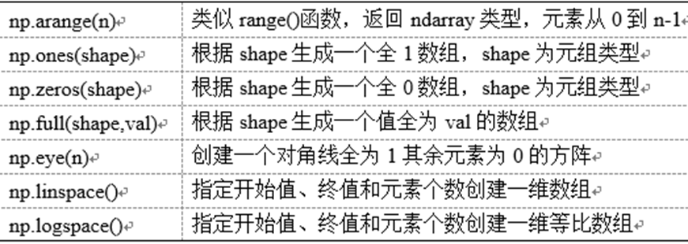

```python
array1 = np.arange(10)
print('array1:',array1)
array2 = np.arange(0,1,0.2)
print('array2:',array2)
```

```
array1: [0 1 2 3 4 5 6 7 8 9]
array2: [0.  0.2 0.4 0.6 0.8]
```

#### 【例2-18】利用linspace和logspace函数创建数组。

```python
array3= np.linspace(0,1,5)
array4 = np.logspace(0,1,5)
#生成1-10间的具有5个元素的等比数列
print('array3:',array3)
print('array4:',array4)
```

```
array3: [0.   0.25 0.5  0.75 1.  ]
array4: [ 1.          1.77827941  3.16227766  5.62341325 10.        ]
```

#### 【例2-19】zeros和ones函数创建。

```python
print('1维值为0的数组：',np.zeros(4))
print('3*3维值为0的数组：\n',np.zeros([3,3]))
print('1维值为0的数组：',np.ones(5))
print('2*3维值为0的数组：\n',np.ones([2,3]))
```

```
1维值为0的数组： [0. 0. 0. 0.]
3*3维值为0的数组：
 [[0. 0. 0.]
 [0. 0. 0.]
 [0. 0. 0.]]
1维值为0的数组： [1. 1. 1. 1. 1.]
2*3维值为0的数组：
 [[1. 1. 1.]
 [1. 1. 1.]]
```

#### 【例2-20】diag和full函数创建矩阵。

```python
print('对角阵：\n',np.diag([1,2,3,4]))
print('指定大小和数值的矩阵:\n',np.full((2,3),9))
```

```
对角阵：
 [[1 0 0 0]
 [0 2 0 0]
 [0 0 3 0]
 [0 0 0 4]]
指定大小和数值的矩阵:
 [[9 9 9]
 [9 9 9]]
```

### ndarray对象属性和数据转换

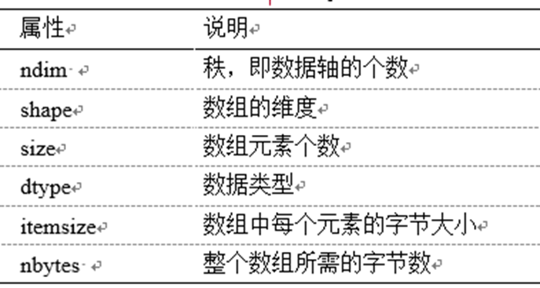

#### 【例2-21】查看数组的属性、设置shape属性及类型转换。

```python
warray = np.array([[1,2,3],[4,5,6]])
print(warray)
print('秩为：',warray.ndim)
print('形状为：',warray.shape)
print('元素个数为：',warray.size)
warray.shape = 3,2                #改变数组维度
print('设置shape后的数组:\n',warray)
print('原数组类型：',warray.dtype)
print('新数据类型',warray.astype(np.float64).dtype)
print(warray)
```

```
[[1 2 3]
 [4 5 6]]
秩为： 2
形状为： (2, 3)
元素个数为： 6
设置shape后的数组:
 [[1 2]
 [3 4]
 [5 6]]
原数组类型： int32
新数据类型 float64
[[1 2]
 [3 4]
 [5 6]]
```

### 生成随机数

#### 【例2-22】生成随机数。

np.random.randint(low,high = None,size = None)

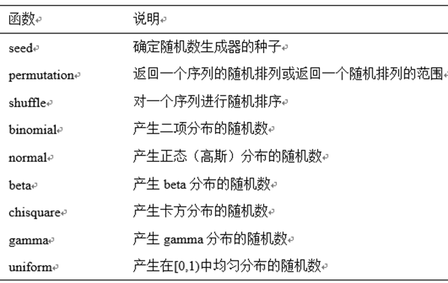

```python
arr1 = np.random.randint(100,200,size = (2,4))  #随机二维数组，数值在100~200的整数
print('arr1:\n',arr1)
arr2 = np.random.rand(5) #0~1之间
print('arr2:\n',arr2)
arr3 = np.random.rand(3,2) #默认为0~1之间
print('arr3:\n',arr3)
```

```
arr1:
 [[151 133 174 131]
 [194 173 186 115]]
arr2:
 [0.83589286 0.11574256 0.91319726 0.46200935 0.59872806]
arr3:
 [[0.13681956 0.6785816 ]
 [0.90453505 0.93687918]
 [0.5315017  0.86124405]]
```

### 数组变换

#### 数组重塑

##### 【例2-23】改变数组维度。

```python
arr1 = np.arange(12)
print('arr1:\n',arr1)
arr2=arr1.reshape(3,4)
print('arr2:\n',arr2)
arr3 = arr1.reshape(2,-1) #reshape()函数的参数可以设置其中一个为-1，表示数组的维度可以通过数据本身推断
print('arr3:\n',arr3)
```

```
arr1:
 [ 0  1  2  3  4  5  6  7  8  9 10 11]
arr2:
 [[ 0  1  2  3]
 [ 4  5  6  7]
 [ 8  9 10 11]]
arr3:
 [[ 0  1  2  3  4  5]
 [ 6  7  8  9 10 11]]
```

##### 【例2-24】数据散开和数据扁平化。

```python
arr1 = np.arange(12).reshape(3,4)
print('arr1:\n',arr1)
arr2 = arr1.ravel()  #数据散开
print('arr2:',arr2)
arr3 = arr1.flatten()  #数据扁平化
print('arr3:',arr3)
```

```
arr1:
 [[ 0  1  2  3]
 [ 4  5  6  7]
 [ 8  9 10 11]]
arr2: [ 0  1  2  3  4  5  6  7  8  9 10 11]
arr3: [ 0  1  2  3  4  5  6  7  8  9 10 11]
```

#### 数组合并

##### 【例2-25】两个数组组合。

```python
arr1 = np.arange(6).reshape(3,2)
print("arr1:\n",arr1)
arr2 = arr1*2
print("arr2:\n",arr2)
arr3 = np.hstack((arr1,arr2))  #横向合并
print('横向合并：\n',arr3)
arr4 = np.vstack((arr1,arr2)) #纵向合并
print('纵向合并：\n',arr4)
```

```
arr1:
 [[0 1]
 [2 3]
 [4 5]]
arr2:
 [[ 0  2]
 [ 4  6]
 [ 8 10]]
横向合并：
 [[ 0  1  0  2]
 [ 2  3  4  6]
 [ 4  5  8 10]]
纵向合并：
 [[ 0  1]
 [ 2  3]
 [ 4  5]
 [ 0  2]
 [ 4  6]
 [ 8 10]]
```

##### 【例2-26】concatenate函数合并数组。

```python
arr1 = np.arange(6).reshape(3,2)
arr2 = arr1*2
print('横向组合为：\n',np.concatenate((arr1,arr2),axis = 1))
print('纵向组合为：\n',np.concatenate((arr1,arr2),axis = 0))
```

```
横向组合为：
 [[ 0  1  0  2]
 [ 2  3  4  6]
 [ 4  5  8 10]]
纵向组合为：
 [[ 0  1]
 [ 2  3]
 [ 4  5]
 [ 0  2]
 [ 4  6]
 [ 8 10]]
```

#### 数组分割

##### 【例2-27】数组的分割。

```python
arr = np.arange(16).reshape(4,4)
print('原数组为:\n',arr)
print('横向分割为:\n',np.hsplit(arr,2))
print('纵向分割为:\n',np.vsplit(arr,2))
```

```
原数组为:
 [[ 0  1  2  3]
 [ 4  5  6  7]
 [ 8  9 10 11]
 [12 13 14 15]]
横向分割为:
 [array([[ 0,  1],
       [ 4,  5],
       [ 8,  9],
       [12, 13]]), array([[ 2,  3],
       [ 6,  7],
       [10, 11],
       [14, 15]])]
纵向分割为:
 [array([[0, 1, 2, 3],
       [4, 5, 6, 7]]), array([[ 8,  9, 10, 11],
       [12, 13, 14, 15]])]
```

#### 矩阵转置和轴兑换

##### 【例2-28】数组利用transpose转置。

```python
arr = np.arange(6).reshape(3,2)
print('矩阵：\n',arr)
print('转置矩阵：\n',arr.transpose((1,0)))
print(arr) #arr本身未变
print('转置矩阵：\n',arr.T) #利用数组的T属性进行转置
print(arr)
```

```
矩阵：
 [[0 1]
 [2 3]
 [4 5]]
转置矩阵：
 [[0 2 4]
 [1 3 5]]
[[0 1]
 [2 3]
 [4 5]]
转置矩阵：
 [[0 2 4]
 [1 3 5]]
[[0 1]
 [2 3]
 [4 5]]
```

#### 数组的索引和切片

##### 【例2-29】一维数组的索引。

```python
arr = np.arange(10)
print(arr)
print(arr[2])
print(arr[-1])
print(arr[1:4])
print(arr)
```

```
[0 1 2 3 4 5 6 7 8 9]
2
9
[1 2 3]
[0 1 2 3 4 5 6 7 8 9]
```

##### 【例2-30】数组元素的复制。

```python
#arr1 = arr[-4:-1].copy()
arr1 = arr[-4:-1]  #可以直接赋值，不用copy
print(arr)
print(arr1)
```

```
[0 1 2 3 4 5 6 7 8 9]
[6 7 8]
```

##### 【例2-31】多维数组的索引。

```python
import numpy as np
arr = np.arange(12).reshape(3,4)
print(arr)
print(arr[0,1:3])  #索引第0行中第1列到第2列的元素
print(arr[:,2])   #索引第2列元素
print('索引结果1：',arr[(0,1),(1,3)]) #索引第0行且第1列和第1行且第3列的元素

print('索引结果2：',arr[1:2,(0,2,3)]) #索引第1、2行中第0、2、3列的元素

mask = np.array([1,0,1],dtype = np.bool)
print('索引结果3：',arr[mask,1])  #mask是一个布尔数组，它索引第0,2行中    第1列元素
```

```
[[ 0  1  2  3]
 [ 4  5  6  7]
 [ 8  9 10 11]]
[1 2]
[ 2  6 10]
索引结果1： [1 7]
索引结果2： [[4 6 7]]
索引结果3： [1 9]
```

#### 数组的运算

##### 【例2-32】数组元素的追加。

```python
a = [1,2,3]
b = []
for i in a:
    b.append(i*i)
print('b数组：',b)
wy = np.array([1,2,3])
c = wy*2
print('c数组：',c)
```

```
b数组： [1, 4, 9]
c数组： [2 4 6]
```

##### 【例2-33】数组的四则运算。

```python
x = np.array([1,2,3])
y = np.array([4,5,6])
print('数组相加结果：',x+y)
print('数组相减结果：',x-y)
print('数组相乘结果：',x*y)
print('数组幂运算结果：',x**y)
```

```
数组相加结果： [5 7 9]
数组相减结果： [-3 -3 -3]
数组相乘结果： [ 4 10 18]
数组幂运算结果： [  1  32 729]
```

##### 【例2-34】数组的比较运算。

```python
x = np.array([1,3,6])
y = np.array([2,3,4])
print('比较结果(<)：',x<y)
print('比较结果(>)：',x>y)
print('比较结果(==)：',x==y)
print('比较结果(>=)：',x>=y)
print('比较结果(!=)：',x!=y)
```

```
比较结果(<)： [ True False False]
比较结果(>)： [False False  True]
比较结果(==)： [False  True False]
比较结果(>=)： [False  True  True]
比较结果(!=)： [ True False  True]
```

##### 【例2-35】ufunc函数的广播。（Broadcasting 广播机制指不同形状的数组之间执行算术运算的方式）

```python
arr1 = np.array([[0,0,0],[1,1,1],[2,2,2]])
arr2 = np.array([1,2,3])
print('arr1:\n',arr1)
print('arr2:\n',arr2)
print('arr1+arr2:\n',arr1+arr2)
```

```
arr1:
 [[0 0 0]
 [1 1 1]
 [2 2 2]]
arr2:
 [1 2 3]
arr1+arr2:
 [[1 2 3]
 [2 3 4]
 [3 4 5]]
```

##### 【例2-36】数组的条件逻辑运算。

```python
arr1 = np.array([1,3,5,7])
arr2 = np.array([2,4,6,8])
cond = np.array([True,False,True,False])
result = [(x if c else y)for x,y,c in zip(arr1,arr2,cond)]
print(result)
```

```
[1, 4, 5, 8]
```

##### 【例2-37】where的基本用法。

np.where(condition,x,y),满足条件condition则输出x，不满足则输出y

```python
print(np.where([[True,False], [True,True]],  [[1,2], [3,4]],  [[9,8], [7,6]]))

w = np.array([2,5,6,3,10])

print(np.where(w>4)) #输出对应值大于5的index
```

```
[[1 8]
 [3 4]]
(array([1, 2, 4], dtype=int64),)
```

#### Numpy中的数据统计与分析

##### 【例2-38】使用sort函数进行排序。

注意：直接改变原始数组！

```python
import numpy as np
arr = np.array([7,9,5,2,9,4,3,1,4,3])
print('原数组：',arr)
arr.sort()
print('排序后：',arr)
```

```
原数组： [7 9 5 2 9 4 3 1 4 3]
排序后： [1 2 3 3 4 4 5 7 9 9]
```

##### 【例2-39】带轴向参数的sort排序。

```python
arr = np.array([[4,2,9,5],[6,4,8,3],[1,6,2,4]])
print('原数组：\n',arr)
arr.sort(axis = 1)   #沿横向排序
print('横向排序后：\n',arr)
```

```
原数组：
 [[4 2 9 5]
 [6 4 8 3]
 [1 6 2 4]]
横向排序后：
 [[2 4 5 9]
 [3 4 6 8]
 [1 2 4 6]]
```

##### 【例2-40】使用argsort和lexsort函数进行排序。

```python
#对名称进行排序：首先按姓氏，然后按名称。
surnames = ('Hertz', 'Galilei', 'Hertz')
first_names = ('Heinrich', 'Galileo', 'Gustav')

ind = np.lexsort((first_names, surnames)) # Sort by surnames, then by first_names，原数组不变

print(ind)

#array([1, 2, 0])
print([surnames[i] + ", " + first_names[i] for i in ind])
```

```
[1 2 0]
['Galilei, Galileo', 'Hertz, Gustav', 'Hertz, Heinrich']
```

```python
#对两列数字进行排序：
a = [1,5,1,4,3,4,4] # First column

b = [9,4,0,4,0,2,1] # Second column

ind = np.lexsort((b,a)) # Sort by a, then by b,原数组不变

ind

#array([2, 0, 4, 6, 5, 3, 1])
print([(a[i],b[i]) for i in ind])
print(a)
print(b)
```

```
[(1, 0), (1, 9), (3, 0), (4, 1), (4, 2), (4, 4), (5, 4)]
[1, 5, 1, 4, 3, 4, 4]
[9, 4, 0, 4, 0, 2, 1]
```

```python
arr = np.array([7,9,5,2,9,4,3,1,4,3])
print('原数组：',arr)
print('排序后：',arr.argsort())  #返回值为数组排序后的下标排列
print(arr) #依旧不会改变原数组
a=[2,5,8,4,3,7,6]
b=[9,4,0,4,0,2,1]
c=np.lexsort((a,b))
print(c)
```

```
原数组： [7 9 5 2 9 4 3 1 4 3]
排序后： [7 3 6 9 5 8 2 0 1 4]
[7 9 5 2 9 4 3 1 4 3]
[4 2 6 5 3 1 0]
```

##### 【例2-41】数组内数据去重。

unique()找到数组的唯一值并返回已排序的结果,不改变原数组

```python
import numpy as np
names = np.array(['红色','蓝色','黄色','白色','红色'])
print('原数组：',names)
print('去重后的数组：',np.unique(names))
print(names)
```

```
原数组： ['红色' '蓝色' '黄色' '白色' '红色']
去重后的数组： ['白色' '红色' '蓝色' '黄色']
['红色' '蓝色' '黄色' '白色' '红色']
```

##### 【例2-42】使用tile函数实现数据重复。

```python
arr = np.arange(5)
print('原数组：',arr)
wy = np.tile(arr,3)
print('重复数据处理：\n',wy)
```

```
原数组： [0 1 2 3 4]
重复数据处理：
 [0 1 2 3 4 0 1 2 3 4 0 1 2 3 4]
```

##### 【例2-43】使用repeat函数实现数据重复。

numpy.repeat(a,reps,axis=None),a为需要重复的数组元素，reps重复次数，axis=0 按行重复，=1按列重复

```python
import numpy as np
arr1 = np.arange(5)
print('原数组：',arr1)
w1 = np.tile(arr1,3)
print('原数组重复3次：\n',np.tile(arr1,3))
print('原数组重复3次：\n',w1)
arr2 = np.array([[1,2,3],[4,5,6]])
print('重复数据处理：\n',arr2.repeat(2,axis=1))
print('重复数据处理：\n',arr2.repeat(2,axis=0))
```

```
原数组： [0 1 2 3 4]
原数组重复3次：
 [0 1 2 3 4 0 1 2 3 4 0 1 2 3 4]
原数组重复3次：
 [0 1 2 3 4 0 1 2 3 4 0 1 2 3 4]
重复数据处理：
 [[1 1 2 2 3 3]
 [4 4 5 5 6 6]]
重复数据处理：
 [[1 2 3]
 [1 2 3]
 [4 5 6]
 [4 5 6]]
```

##### 【例2-44】NumPy中常用函数的使用。

二维数组注意轴axis

```python
arr = np.arange(20).reshape(4,5)
print('创建的数组：\n',arr)
print('数组的和：',np.sum(arr))
print('数组纵轴的和：',np.sum(arr,axis = 0))
print('数组横轴的和：',np.sum(arr,axis = 1))
print('数组的均值：',np.mean(arr))
print('数组横轴的均值：',np.mean(arr,axis = 1))
print('数组的标准差：',np.std(arr))
print('数组横轴的标准差：',np.std(arr,axis = 1))
```

```
创建的数组：
 [[ 0  1  2  3  4]
 [ 5  6  7  8  9]
 [10 11 12 13 14]
 [15 16 17 18 19]]
数组的和： 190
数组纵轴的和： [30 34 38 42 46]
数组横轴的和： [10 35 60 85]
数组的均值： 9.5
数组横轴的均值： [ 2.  7. 12. 17.]
数组的标准差： 5.766281297335398
数组横轴的标准差： [1.41421356 1.41421356 1.41421356 1.41421356]
```

## Pandas统计分析基础

### Pandas中的数据结构

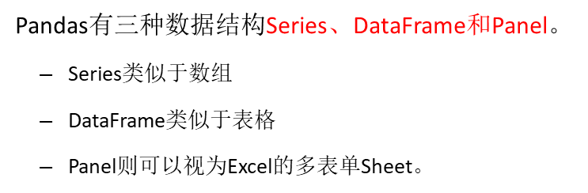

#### Series

##### 【例2-45】通过列表创建Series。

```python
import pandas as pd
obj1 = pd.Series([1, -2, 3, -4])
print(obj1)
i = ["a", "c", "d", "a"]
v = [2, 4, 5, 7]
obj2 = pd.Series(v, index = i, name = "col")
print(obj2)
```

```
0    1
1   -2
2    3
3   -4
dtype: int64
a    2
c    4
d    5
a    7
Name: col, dtype: int64
```

##### 【例2-46】通过字典创建Series。

```python
sdata = {'Ohio': 35000, 'Texas': 71000, 'Oregon': 16000, 'Utah': 5000}
obj3 = pd.Series(sdata, name = "col1")
print(obj3)
```

```
Ohio      35000
Texas     71000
Oregon    16000
Utah       5000
Name: col1, dtype: int64
```

##### 【例2-47】不同索引数据的自动对齐。

Series域的重要功能：算术运算中自动对齐不同索引数据

```python
sdata = {'Ohio': 35000, 'Texas': 71000, 'Oregon': 16000, 'Utah': 5000}
obj1 = pd.Series(sdata)
print(obj1)
states = ['California', 'Ohio', 'Oregon', 'Texas']
obj2 = pd.Series(sdata, index = states)
print(obj2)
print(obj1+obj2)
```

```
Ohio      35000
Texas     71000
Oregon    16000
Utah       5000
dtype: int64
California        NaN
Ohio          35000.0
Oregon        16000.0
Texas         71000.0
dtype: float64
California         NaN
Ohio           70000.0
Oregon         32000.0
Texas         142000.0
Utah               NaN
dtype: float64
```

【例2-48】Series索引的修改。

```python
obj = pd.Series([4,7,-3,2])
obj.index = ['Bob', 'Steve', 'Jeff', 'Ryan']
print(obj)
```

```
Bob      4
Steve    7
Jeff    -3
Ryan     2
dtype: int64
```

#### DataFrame

##### 【例2-49】DataFrame的索引。

```python
data = {
    'name':['张三', '李四', '王五', '小明'],
    'sex':['female', 'female', 'male', 'male'],
    'year':[2001, 2001, 2003, 2002],
    'city':['北京', '上海', '广州', '北京']
}
df1= pd.DataFrame(data)
display(df1)
df2= pd.DataFrame(data, columns = ['name', 'year', 'sex', 'city'])
display(df2)
print(df2['name'])
display(df2.loc[[0]])
display(df2.iloc[:,0])
print(df2.iloc[0,:])
```

|  | name | sex | year | city |
| --- | --- | --- | --- | --- |
| 0 | 张三 | female | 2001 | 北京 |
| 1 | 李四 | female | 2001 | 上海 |
| 2 | 王五 | male | 2003 | 广州 |
| 3 | 小明 | male | 2002 | 北京 |

|  | name | year | sex | city |
| --- | --- | --- | --- | --- |
| 0 | 张三 | 2001 | female | 北京 |
| 1 | 李四 | 2001 | female | 上海 |
| 2 | 王五 | 2003 | male | 广州 |
| 3 | 小明 | 2002 | male | 北京 |

```
0    张三
1    李四
2    王五
3    小明
Name: name, dtype: object
```

|  | name | year | sex | city |
| --- | --- | --- | --- | --- |
| 0 | 张三 | 2001 | female | 北京 |

```
0    张三
1    李四
2    王五
3    小明
Name: name, dtype: object
```

```
name        张三
year      2001
sex     female
city        北京
Name: 0, dtype: object
```

### 索引对象

【例2-50】显示DataFrame的索引和列。

```python
display(df1)
print(df1.index)
print(df1.columns)
```

|  | name | sex | year | city |
| --- | --- | --- | --- | --- |
| 0 | 张三 | female | 2001 | 北京 |
| 1 | 李四 | female | 2001 | 上海 |
| 2 | 王五 | male | 2003 | 广州 |
| 3 | 小明 | male | 2002 | 北京 |

```
RangeIndex(start=0, stop=4, step=1)
Index(['name', 'sex', 'year', 'city'], dtype='object')
```

#### 重建索引

##### 【例2-51】重建索引

```python
obj = pd.Series([7.2,-3.3,3.5,3.6],index = ['b', 'a',
'd', 'c'])
obj.reindex(['a','b','c','d','e'])
```

```
a   -3.3
b    7.2
c    3.6
d    3.5
e    NaN
dtype: float64
```

【例2-52】重建索引时填充缺失值。

对于顺序数据，比如时间序列，重新索引时可能需要进行插值或填值处理，利用参数method选项可以设置：

method = ‘ffill’或‘pad’，表示前向值填充

method = ‘bfill’或‘backfill’，表示后向值填充

```python
obj.reindex(['a', 'b', 'c', 'd', 'e'], fill_value = 0)
```

```
a   -3.3
b    7.2
c    3.6
d    3.5
e    0.0
dtype: float64
```

##### 【例2-53】缺失值的前向填充。

```python
import numpy as np
obj1 = pd.Series(['blue','red','black'],index = [0,2,4])
obj1.reindex(np.arange(6),method = 'ffill')
```

```
0     blue
1     blue
2      red
3      red
4    black
5    black
dtype: object
```

##### 【例2-54】DataFrame数据。

```python
df2 = pd.DataFrame(np.arange(9).reshape(3,3),
index = ['a','c','d'],columns = ['one','two','four'])
display(df2)
df2.reindex(index = ['a','b','c','d'],columns = ['one','two','three','four'])
```

|  | one | two | four |
| --- | --- | --- | --- |
| a | 0 | 1 | 2 |
| c | 3 | 4 | 5 |
| d | 6 | 7 | 8 |

|  | one | two | three | four |
| --- | --- | --- | --- | --- |
| a | 0.0 | 1.0 | NaN | 2.0 |
| b | NaN | NaN | NaN | NaN |
| c | 3.0 | 4.0 | NaN | 5.0 |
| d | 6.0 | 7.0 | NaN | 8.0 |

##### 【例2-55】传入fill_value = n填充缺失值。

```python
df2.reindex(index = ['a','b','c','d'],columns = ['one','two','three','four'], fill_value = 100)
```

|  | one | two | three | four |
| --- | --- | --- | --- | --- |
| a | 0 | 1 | 100 | 2 |
| b | 100 | 100 | 100 | 100 |
| c | 3 | 4 | 100 | 5 |
| d | 6 | 7 | 100 | 8 |

#### 更换索引

##### 【例2-56】更换索引。

```python
df3=df1.set_index('city') #将city列数据作为索引
display(df3)
```

| city | name | sex | year |
| --- | --- | --- | --- |
| 北京 | 张三 | female | 2001 |
| 上海 | 李四 | female | 2001 |
| 广州 | 王五 | male | 2003 |
| 北京 | 小明 | male | 2002 |

#### 查看DF常用属性

##### 【例2-57】显示DataFrame的属性。

```python
print('信息表的所有值为：\n',df3.values)
print('信息表的所有列为：\n',df3.columns)
print('信息表的元素个数为：',df3.size)
print('信息表的维度是：',df3.ndim)
print('信息表的形状为：',df3.shape)
```

```
信息表的所有值为：
 [['张三' 'female' 2001]
 ['李四' 'female' 2001]
 ['王五' 'male' 2003]
 ['小明' 'male' 2002]]
信息表的所有列为：
 Index(['name', 'sex', 'year'], dtype='object')
信息表的元素个数为： 12
信息表的维度是： 2
信息表的形状为： (4, 3)
```

### DF的数据查询与编辑

#### DF数据查询

##### 【例2-58】选取列数据。

```python
df3=df3.reset_index()
df3=df3.set_index('city')
w1 = df3['name']
print('选取1列数据：\n',w1)
w2 = df3[['name','year']]
print('选取2列数据：\n',w2)
```

```
选取1列数据：
 city
北京    张三
上海    李四
广州    王五
北京    小明
Name: name, dtype: object
选取2列数据：
      name  year
city
北京     张三  2001
上海     李四  2001
广州     王五  2003
北京     小明  2002
```

##### 【例2-59】选取行数据。

```python
display(df3)
print('显示前2行:\n',df3[:2])  #切片方式选取第0~1行
print('显示2-3两行:\n',df3[1:3])  #切片方式选取第1~2行
print('随机显示两行:\n',df3.sample(2))
```

| city | name | sex | year |
| --- | --- | --- | --- |
| 北京 | 张三 | female | 2001 |
| 上海 | 李四 | female | 2001 |
| 广州 | 王五 | male | 2003 |
| 北京 | 小明 | male | 2002 |

```
显示前2行:
      name     sex  year
city
北京     张三  female  2001
上海     李四  female  2001
显示2-3两行:
      name     sex  year
city
上海     李四  female  2001
广州     王五    male  2003
随机显示两行:
      name     sex  year
city
北京     张三  female  2001
上海     李四  female  2001
```

##### 【例2-60】利用loc和iloc选取行和列。

```python
display(df3.loc[:,['name','year']] )  #显示name和year两列
display(df3.iloc[[1,3]])  #显示第1和第3行
display(df3.iloc[[1,3],[1,2]])
```

| city | name | year |
| --- | --- | --- |
| 北京 | 张三 | 2001 |
| 上海 | 李四 | 2001 |
| 广州 | 王五 | 2003 |
| 北京 | 小明 | 2002 |

| city | name | sex | year |
| --- | --- | --- | --- |
| 上海 | 李四 | female | 2001 |
| 北京 | 小明 | male | 2002 |

| city | sex | year |
| --- | --- | --- |
| 上海 | female | 2001 |
| 北京 | male | 2002 |

```python
print(df3.loc[df3['year'].isin(['2001','2003'])])
```

```
Empty DataFrame
Columns: [name, sex, year]
Index: []
```

##### 【例2-61】布尔选择。

```python
df3[df3['year']==2001]
```

| city | name | sex | year |
| --- | --- | --- | --- |
| 北京 | 张三 | female | 2001 |
| 上海 | 李四 | female | 2001 |

```python
df = pd.DataFrame({'price': [1.99, 3, 5, 0.5, 3.5, 5.5, 3.9]})

df[(df.price >= 2) & (df.price <= 4)]
```

|  | price |
| --- | --- |
| 1 | 3.0 |
| 4 | 3.5 |
| 6 | 3.9 |

DataFrame行和列的选取还可以通过Pandas的query方法实现。

用法：

pandas.DataFrame.query(self, expr, inplace = False, **kwargs)

1. 作用：

   使用布尔表达式查询DataFrame的列，也就是按照DataFrame中某列的规则进行过滤操作
2. 参数：

   expr：

   ```
   要评估的查询字符串；
   可以在环境中引用变量，在变量前面加上@字符（@a+b）；
   也可以通过在反引号中将空格或运算符括起来来引用它们
   ```

   inplace=False：查询是应该修改数据还是返回修改后的副本 kwargs：dict关键字参数
3. 返回值类型：

   DataFrame，由提供的查询表达式产生的DataFrame

```python
display(df3.query(' year>2001'))

display(df3.query('year>2001 & year<2003'))

name1='王五'
df3.query('name==@name1')
```

| city | name | sex | year |
| --- | --- | --- | --- |
| 广州 | 王五 | male | 2003 |
| 北京 | 小明 | male | 2002 |

| city | name | sex | year |
| --- | --- | --- | --- |
| 北京 | 小明 | male | 2002 |

| city | name | sex | year |
| --- | --- | --- | --- |
| 广州 | 王五 | male | 2003 |

#### 数据编辑

##### 【例2-62】增加数据。

```python
data1 = {'city':'兰州','name':'小军','year':2005,'sex':'female'}
df4=df3.append(data1,ignore_index = True)  #增加1行
df4['age'] = 20   #增加列“age”
df4['C'] = [85,78,96,80,93]   #增加列“C”
display(df4)
```

|  | name | sex | year | city | age | C |
| --- | --- | --- | --- | --- | --- | --- |
| 0 | 张三 | female | 2001 | NaN | 20 | 85 |
| 1 | 李四 | female | 2001 | NaN | 20 | 78 |
| 2 | 王五 | male | 2003 | NaN | 20 | 96 |
| 3 | 小明 | male | 2002 | NaN | 20 | 80 |
| 4 | 小军 | female | 2005 | 兰州 | 20 | 93 |

##### 【例2-63】删除数据。

```python
df3=df1.set_index('city') #将city列数据作为索引
display(df3)


df3.drop('sex',axis = 1,inplace = True)   #删除sex列
display(df3)
display(df3.drop('北京'))  #删除行索引为'北京'的行，inplace=False,原数据没变
```

| city | name | sex | year |
| --- | --- | --- | --- |
| 北京 | 张三 | female | 2001 |
| 上海 | 李四 | female | 2001 |
| 广州 | 王五 | male | 2003 |
| 北京 | 小明 | male | 2002 |

| city | name | year |
| --- | --- | --- |
| 北京 | 张三 | 2001 |
| 上海 | 李四 | 2001 |
| 广州 | 王五 | 2003 |
| 北京 | 小明 | 2002 |

| city | name | year |
| --- | --- | --- |
| 上海 | 李四 | 2001 |
| 广州 | 王五 | 2003 |

此外，还可以使用replace进行数据的替换，用法如下：

DataFrame.replace(to_replace=None,value=None,inplace=False,limit=None,regex=False,method='pad')

其中主要参数 to_replace 表示被替换的值，value 表示替换后的值。同时替换多个值时使用字典数据。

如DataFrame.replace({'B':'E','C':'F'})表示将表中的B替换为E，C替换为F。

```python
df3.replace({'李四':'李一'})
```

| city | name | year |
| --- | --- | --- |
| 北京 | 张三 | 2001 |
| 上海 | 李一 | 2001 |
| 广州 | 王五 | 2003 |
| 北京 | 小明 | 2002 |

修改列名

Pandas通过 DataFrame.rename() 函数，传入需要修改列名的字典形式来修改列名。

df5.rename(columns={'no':'number'}, inplace=True)

display(df5)

```python
display(df3.rename(columns={'name':'性别'}))
df3
```

| city | 性别 | year |
| --- | --- | --- |
| 北京 | 张三 | 2001 |
| 上海 | 李四 | 2001 |
| 广州 | 王五 | 2003 |
| 北京 | 小明 | 2002 |

| city | name | year |
| --- | --- | --- |
| 北京 | 张三 | 2001 |
| 上海 | 李四 | 2001 |
| 广州 | 王五 | 2003 |
| 北京 | 小明 | 2002 |

#### Pandas数据运算

##### 【例2-64】DataFrame类型的数据相加。

如果有相同索引则进行算术运算，如果没有则会进行数据对齐，但会引入缺失值。

```python
import numpy as np
import pandas as pd
a = np.arange(6).reshape(2,3)
b = np.arange(4).reshape(2,2)
df1 = pd.DataFrame(a,columns = ['a','b','e'],index = ['A','C'])
print('df1:\n',df1)
df2 = pd.DataFrame(b,columns = ['a','b'],index = ['A','D'])
print('df2:\n',df2)
print('df1+df2:\n',df1+df2)
```

```
df1:
    a  b  e
A  0  1  2
C  3  4  5
df2:
    a  b
A  0  1
D  2  3
df1+df2:
      a    b   e
A  0.0  2.0 NaN
C  NaN  NaN NaN
D  NaN  NaN NaN
```

函数应用和映射:在数据分析时，经常会对数据进行较复杂的运算，此时需要定义函数。

定义好的函数可以应用到pandas数据中，其中有三种方法：

map 函数，将函数套用到 Series 的每个元素中；

apply 函数，将函数套用到 DataFrame 的行与列上，行与列通过 axis 参数设置；

applymap 函数，将函数套用到 DataFrame 的每个元素上。

#### 函数应用与映射

##### 【例2-65】将水果价格表中的“元”去掉。

```python
data = {'fruit':['apple','grape','banana'],'price':['30元','43元','28元']}
df1 = pd.DataFrame(data)
print(df1)
def f(x):
    #print(x.split('元') )
    return x.split('元')[0] #以“元”为分隔符进行分割
df1['price'] = df1['price'].map(f) #将函数f套用到df1['price'] Series的每个元素上
print('修改后的数据表:\n',df1)
```

```
    fruit price
0   apple   30元
1   grape   43元
2  banana   28元
修改后的数据表:
     fruit price
0   apple    30
1   grape    43
2  banana    28
```

##### 【例2-66】apply函数的使用方法。

```python
df2 = pd.DataFrame(np.random.randn(3,3),columns = ['a','b','c'],
index = ['app','win','mac'])  #np.random.randn创建一个3*3二维数组，数组元素符合标准正态分布N(0,1)
print(df2)
print(df2.apply(np.mean,axis=1)) #将函数套用到DataFrame的行与列上，行与列通过axis参数设置,axis=1 对应行
print(df2.apply(np.mean))
```

```
            a         b         c
app  2.066611  1.547410 -0.325482
win -0.258044 -1.063625  0.042858
mac  1.512525  1.922516 -0.616269
app    1.096180
win   -0.426270
mac    0.939591
dtype: float64
a    1.107031
b    0.802100
c   -0.299631
dtype: float64
```

##### 【例2-67】applymap函数的用法。

```python
print(df2)
df2.applymap(lambda x:'%.3f'%x) #将函数套用到DataFrame的每个元素上
```

```
            a         b         c
app  2.066611  1.547410 -0.325482
win -0.258044 -1.063625  0.042858
mac  1.512525  1.922516 -0.616269
```

|  | a | b | c |
| --- | --- | --- | --- |
| app | 2.067 | 1.547 | -0.325 |
| win | -0.258 | -1.064 | 0.043 |
| mac | 1.513 | 1.923 | -0.616 |

#### 排序

##### 【例2-68】Series的排序。

```python
wy = pd.Series([1,-2,4,-4],index = ['c','b','a','d'])
print(wy)
print('排序后的Series:\n',wy.sort_index(ascending=False))  #对索引排序 ，默认升序，ascending=False降序
print('值排序后的Series:\n',wy.sort_values())  #对数值排序
```

```
c    1
b   -2
a    4
d   -4
dtype: int64
排序后的Series:
 d   -4
c    1
b   -2
a    4
dtype: int64
值排序后的Series:
 d   -4
b   -2
c    1
a    4
dtype: int64
```

##### 【例2-69】DataFrame排序。

```python
print(df2)
df2.sort_values(by = 'a')            #axis默认为0——列  列名传给by 参数
df2.sort_values(by = 'app',axis=1)   #axis 为1——行  行名传给by 参数
```

```
            a         b         c
app  2.066611  1.547410 -0.325482
win -0.258044 -1.063625  0.042858
mac  1.512525  1.922516 -0.616269
```

|  | c | b | a |
| --- | --- | --- | --- |
| app | -0.325482 | 1.547410 | 2.066611 |
| win | 0.042858 | -1.063625 | -0.258044 |
| mac | -0.616269 | 1.922516 | 1.512525 |

#### 汇总与统计

##### 【例2-70】DataFrame中的汇总。

```python
print('按列汇总:\n',df2.sum())  #按列汇总
print('按行汇总:\n',df2.sum(axis = 1)) #按行汇总
```

```
按列汇总:
 a    3.321092
b    2.406301
c   -0.898893
dtype: float64
按行汇总:
 app    3.288539
win   -1.278811
mac    2.818772
dtype: float64
```

##### 【例2-71】describe示例。

```python
df2.describe()
```

|  | a | b | c |
| --- | --- | --- | --- |
| count | 3.000000 | 3.000000 | 3.000000 |
| mean | 1.107031 | 0.802100 | -0.299631 |
| std | 1.214218 | 1.626614 | 0.330323 |
| min | -0.258044 | -1.063625 | -0.616269 |
| 25% | 0.627241 | 0.241892 | -0.470876 |
| 50% | 1.512525 | 1.547410 | -0.325482 |
| 75% | 1.789568 | 1.734963 | -0.141312 |
| max | 2.066611 | 1.922516 | 0.042858 |

##### 【例2-72】数据的频数统计。

```python
obj = pd.Series(['a','b','c','a','d','c'])
print(obj.unique())  #获取不重复的数组，输出序列唯一值
print(obj.value_counts())  #实现频数统计
```

```
['a' 'b' 'c' 'd']
a    2
c    2
b    1
d    1
dtype: int64
```

#### 数据分组

##### 【例2-73】groupby基本用法举例。

```python
import pandas as pd
df = pd.DataFrame({'Q':['LI','ZHANG','ZHANG','LI','WANG'], 'A' : [1,1,1,2,2], 'B' : [1,-1,0,1,2], 'C' : [3,4,5,6,7]})
df.groupby('Q').apply(lambda x:print(x))
```

```
    Q  A  B  C
0  LI  1  1  3
3  LI  2  1  6
      Q  A  B  C
4  WANG  2  2  7
       Q  A  B  C
1  ZHANG  1 -1  4
2  ZHANG  1  0  5
```

```python
df = pd.DataFrame({'key1' : ['a', 'a', 'b', 'b', 'a'],
    'key2' : ['yes', 'no', 'yes', 'yes', 'no'],
    'data1' : np.random.randn(5),
    'data2' : np.random.randn(5)})
grouped = df['data1'].groupby(df['key1']) #按照key1分组 df['data1']数据分组后返回的数据类型是一个groupby对象
print(df)
print(grouped.size()) #调用对象groupby的方法 size(),返回一个含有分组大小的series
print(grouped.mean())  #调用对象groupby的方法 mean(),返回每个分组数据的均值
print(grouped.max())  #调用对象groupby的方法 size(),返回每个分组数据的最大值
```

```
  key1 key2     data1     data2
0    a  yes -1.208327 -1.572723
1    a   no -0.401188  0.723626
2    b  yes -0.803187  2.114091
3    b  yes -0.232229  0.744844
4    a   no -0.024717 -0.211397
key1
a    3
b    2
Name: data1, dtype: int64
key1
a   -0.544744
b   -0.517708
Name: data1, dtype: float64
key1
a   -0.024717
b   -0.232229
Name: data1, dtype: float64
```

##### 【例2-74】列索引名称作为分组键。

```python
groupk1 = df.groupby('key2').mean() #列索引名作为分组键
groupk1
```

| key2 | data1 | data2 |
| --- | --- | --- |
| no | -0.212952 | 0.256115 |
| yes | -0.747914 | 0.428738 |

##### 【例2-75】按列表或元组分组。

```python
wlist = ['w','w','y','w','y']
df.groupby(wlist).sum()
```

|  | data1 | data2 |
| --- | --- | --- |
| w | -1.841744 | -0.104252 |
| y | -0.827904 | 1.902694 |

##### 【例2-76】通过字典作为分组键，分组时各字母不区分大小写。

```python
df=pd.DataFrame(np.random.normal(size=(6,5)),index=
['a','b','c','A','B','c'])
print("数据为:\n",df)
wdict={'a':'one','A':'one','b':'two','B':'two','c':'three'}
print("分组汇总后的结果为:\n",df.groupby(wdict).sum())   #合并分组后汇总
```

```
数据为:
           0         1         2         3         4
a  1.818738  1.289907 -0.203186 -2.566535  1.597237
b -0.878728 -1.379414 -0.471018 -0.128729  1.076497
c  0.322222  1.323430  1.127138 -0.439714  0.007473
A  1.853323 -0.260548  1.051326  0.321336  0.043318
B -0.586354 -0.170131 -2.386814 -0.372399  0.782647
c  0.930826  0.188607 -1.024163 -1.021587  1.591350
分组汇总后的结果为:
               0         1         2         3         4
one    3.672061  1.029359  0.848141 -2.245199  1.640556
three  1.253048  1.512037  0.102975 -1.461301  1.598824
two   -1.465082 -1.549545 -2.857831 -0.501128  1.859143
```

##### 【例2-77】通过DataFrame最后一列的数值进行正负分组。

按函数分组：函数作为分组键的原理类似于字典，通过映射关系进行分组，但是函数更加灵活。

```python
def judge(x):
    if x>=0:
        return '非负数'
    else:
        return '负数'
df = pd.DataFrame(np.random.randn(4,4))
print(df)
print(df[3].groupby(df[3].map(judge)).sum())
```

```
          0         1         2         3
0 -0.534429  0.563185 -1.489877 -0.679364
1  0.805569  0.767786  0.082637  1.060253
2  0.962382 -0.420023 -1.118455 -0.216452
3  0.886053  0.410080 -0.311188  0.454707
3
负数    -0.895816
非负数    1.514959
Name: 3, dtype: float64
```

#### 数据聚合

聚合运算就是对分组后的数据进行计算，产生标量值的数据转换过程。

##### 【例2-78】使用agg求出当前数据对应的统计量。

```python
data=pd.read_excel('testdata.xlsx')
print(data)

display(data[['淋巴细胞计数','白细胞计数']].agg([np.sum,np.mean,np.std]))

#data.agg({'淋巴细胞计数':np.mean,'血小板计数':np.std})

display(data.agg({'淋巴细胞计数':np.mean,'血小板计数':[np.mean,np.std]}))


print(data.groupby('性别')['血小板计数'].agg(np.mean))  #按“性别”分组统计“血小板计数”
```

```
   序号 性别  淋巴细胞计数  白细胞计数  血小板计数 是否吸烟
0   1  女     2.4    8.5    248    否
1   2  女     2.2    6.2    320    是
2   3  女     1.8    5.8    300    否
3   4  男     2.0    5.6    195    是
4   5  男     2.5    6.6    252    否
5   6  男     1.3    5.2    169    否
```

|  | 淋巴细胞计数 | 白细胞计数 |
| --- | --- | --- |
| sum | 12.200000 | 37.900000 |
| mean | 2.033333 | 6.316667 |
| std | 0.441210 | 1.173740 |

|  | 淋巴细胞计数 | 血小板计数 |
| --- | --- | --- |
| mean | 2.033333 | 247.333333 |
| std | NaN | 58.225996 |

```
性别
女    289.333333
男    205.333333
Name: 血小板计数, dtype: float64
```

##### 【例2-79】as_index参数的用法。

```python
display(data.groupby(['性别','是否吸烟'],as_index = False)['血小板计数'].agg(np.mean))
display(data.groupby(['性别','是否吸烟'])['血小板计数'].agg(np.mean))
```

|  | 性别 | 是否吸烟 | 血小板计数 |
| --- | --- | --- | --- |
| 0 | 女 | 否 | 274.0 |
| 1 | 女 | 是 | 320.0 |
| 2 | 男 | 否 | 210.5 |
| 3 | 男 | 是 | 195.0 |

```
性别  是否吸烟
女   否       274.0
    是       320.0
男   否       210.5
    是       195.0
Name: 血小板计数, dtype: float64
```

##### 通过transform方法可以将运算分布到每一行。

【例2-80】transform方法。

```python
print(data.groupby(['性别','是否吸烟'])['血小板计数']. transform('mean').sample(5))
#print(data.groupby(['性别','是否吸烟'])['血小板计数']. transform('mean'))
```

```
2    274.0
5    210.5
0    274.0
4    210.5
3    195.0
Name: 血小板计数, dtype: float64
```

##### 【例2-81】数据分组后应用apply统计。

```python
data.groupby(['性别','是否吸烟'])['血小板计数'].apply( np.mean)
```

```
性别  是否吸烟
女   否       274.0
    是       320.0
男   否       210.5
    是       195.0
Name: 血小板计数, dtype: float64
```

### Pandas数据读取与存储

Pandas读取csv文件的格式： read_csv(filepath_or_buffer, sep=',', delimiter=None, header='infer', names=None, index_col=None, usecols=None, squeeze=False, ...)

##### 【例2-82】Pandas读取csv的示例：

df1 = pd. read_csv（‘文件路径文件名’）

# 读取CSV文件到DataFrame中

df2 = pd. read_table（‘文件路径文件名’, sep = ‘,’）

# 使用read_table，并指定分隔符

df3 = pd. read_csv（‘文件路径文件名’，names = [‘a’,’b’,---]）

# 文件不包含表头行，允许自动分配默认列名，也可以指定列名

##### （2）读取excel文件

Pandas读取excel文件的格式： pandas.read_excel（io，sheet_name = 0，header = 0，names = None，index_col = None，usecols = None，squeeze = False,dtype = None, ...）

【例2-83】pandas读取excel文件示例

xlsx = pd.excelFile(‘example/ex1.xlsx’)

pd.read_excel(xlsx, ‘Sheet1’)

# 也可以直接利用：

frame = pd.read_excel(‘example/ex1.xlsx’, ‘Sheet1’)

##### （3）读取mysql数据

Pandas读取mysql文件的格式：

pandas.read_sql(sql, con, index_col=None, coerce_float=True, params=None, parse_dates=None, columns=None, chunksize=None)

【例2-84】读取mysql数据示例

import pymysql con =pymysql.connect( host=‘localhost’,user=‘root’,password=‘root’,database=‘test’,port=3306,charset=‘utf8’)

sql_select = ‘select * from a’

df = pd.read_sql(sql_select, con)

##### （4）读取json数据

Json是一种常用的数据交换格式，在前后端的交互中经常用到，也会在存储的时候选择这种格式。

Pandas读取Json数据的格式：

pandas.read_json(path_or_buf=None,orient=None,type=’frame’,lines=False, ...)

#### 文件存储

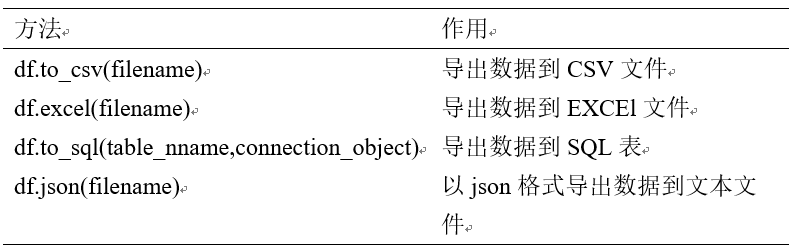

## Matplotlib图表绘制基础

在Jupyter notebook中进行交互式绘图，需要执行一下语句：

%matplotlib notebook

使用matplotlib时，使用的导入惯例为：

import matplotlib.pyplot as plt

### 基础

#### 创建画布与子图

##### 【例2-85】创建子图及绘图。

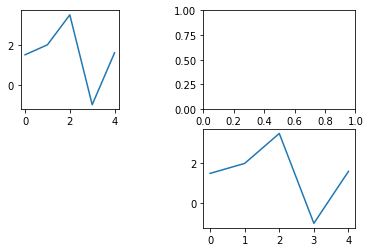

```python
import matplotlib.pyplot as plt
fig = plt.figure()  #创建一张空白画布
#不能使用空白的figure绘图，需要创建子图
ax1 = fig.add_subplot(2,3,1)  #将画布分为2*3=6个区，为其中第1个区
ax2 = fig.add_subplot(2,2,2)
ax3 = fig.add_subplot(2,2,4)
ax1.plot([1.5,2,3.5,-1,1.6])
ax3.plot([1.5,2,3.5,-1,1.6])
```

##### 【例2-86】创建子图调整子图周围的间距。

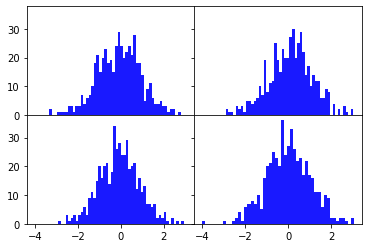

```python
import numpy as np
fig,axes = plt.subplots(2,2,sharex = True,sharey = True) #生成2*2=4个子图,共用x，y轴
for i in range(2):
     for j in range(2):
      axes[i,j].hist(np.random.randn(500),bins =50,color='b',alpha= 0.9) #绘制4个直方图，bin箱个数，alpha透明度（0~1）
plt.subplots_adjust(wspace=0,hspace=0) #子图间距
```

#### 添加画布内容

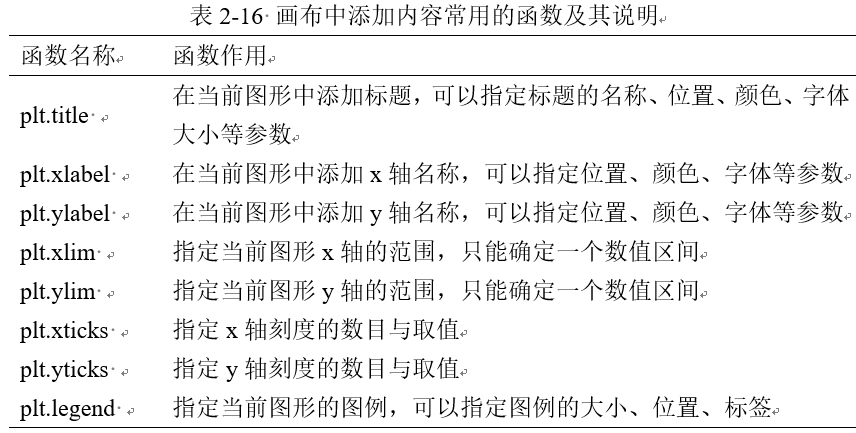

##### 【例2-87】包含子图绘制的基础语法。

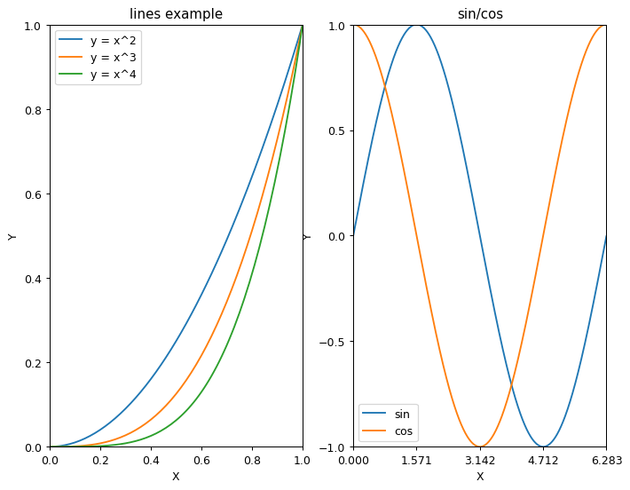

```python
import numpy as np
import matplotlib.pyplot as plt
data = np.arange(0,np.pi*2,0.01)
#print(data)
fig1 = plt.figure(figsize = (9,7),dpi = 90)  #确定画布大小
ax1 = fig1.add_subplot(1,2,1) #绘制第1幅子图
plt.title('lines example')
plt.xlabel('X')
plt.ylabel('Y')
plt.xlim(0,1)
plt.ylim(0,1)
plt.xticks([0,0.2,0.4,0.6,0.8,1])
plt.yticks([0,0.2,0.4,0.6,0.8,1])
plt.plot(data,data**2)
plt.plot(data,data**3)
plt.plot(data,data**4)
plt.legend(['y = x^2','y = x^3','y = x^4'])
ax1 = fig1.add_subplot(1,2,2) #绘制第2幅子图
plt.title('sin/cos')
plt.xlabel('X')
plt.ylabel('Y')
plt.xlim(0,np.pi*2)
plt.ylim(-1,1)
plt.xticks([0,np.pi/2,np.pi,np.pi*3/2,np.pi*2])
plt.yticks([-1,-0.5,0,0.5,1])
plt.plot(data,np.sin(data))
plt.plot(data,np.cos(data))
plt.legend(['sin','cos'])
plt.show()      #本机显示图片
plt.savefig('abc.jpg')     #保存绘制的图片
```

#### 绘图的保存与显示

绘图完成后，需要显示或保存。图形显示和保存的函数只有两个，并且参数不多，见表2-17。

表2-17 绘图显示和保存的函数

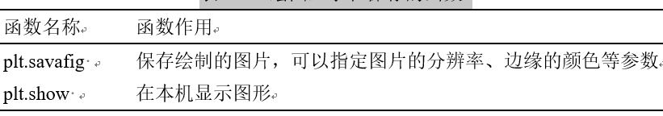

#### 设置pyplot的动态rc参数

【例2-88】查看用户的配置文件5目录。用编辑器打开，修改matplotlibrc文件，即可修改配置参数。

```python
import matplotlib as plt
print(plt.matplotlib_fname())  #查看配置文件目录
print(plt.rc_params())  #查看rc参数
#显示当前用户的配置文件目录
```

[output not shown]

[output cut: 245 more lines]

[output not shown]

rc参数设置 使用Python编程进行配置修改rc参数，rc参数名称及其取值见表2-18至2-20。

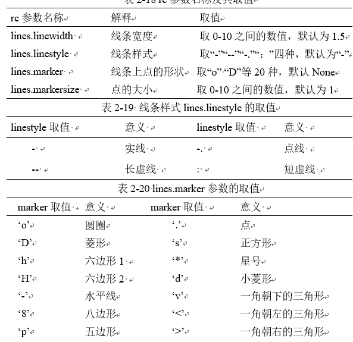

##### 【例2-89】rc参数设置示例。

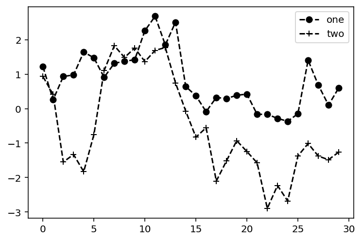

```python
import numpy as np
import matplotlib.pyplot as plt
fig = plt.figure()
ax = fig.add_subplot(1,1,1)
np.random.seed(719)  #设置随机种子
ax.plot(np.random.randn(30).cumsum(),color = 'k',linestyle = 'dashed',marker = 'o',label = 'one')
ax.plot(np.random.randn(30).cumsum(),color = 'k',linestyle = 'dashed',marker = '+',label = 'two')
ax.legend(loc = 'best')  #设置图例位置
#ax.legend(loc = 'lower left')
```

可以用set_xticks设置刻度，用set_xticklabels改变刻度，设置刻度的旋转角度及字体等，如ax.set_xticklabels(['x1','x2','x3','x4','x5'],rotation = 30,fontsize = 'large')。

#### 文本注解

绘图时有时需要在图表中加文本注解，Python通过text函数在指定的位置（x,y）加入文本注解，也可以利用annotate()完成指向型注释。

##### 【例2-90】绘制曲线图并标注。

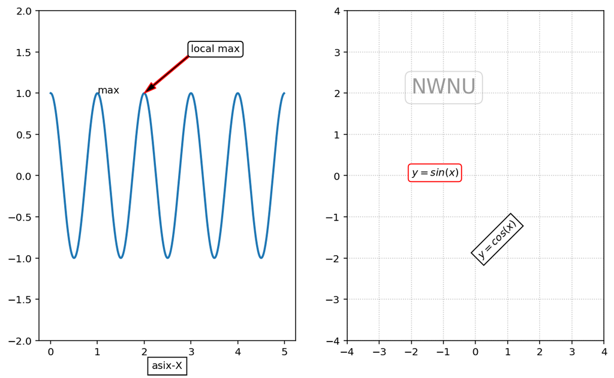

```python
import matplotlib.pyplot as plt
import numpy as np
fig=plt.figure(figsize=(10,6))
ax1=fig.add_subplot(121)
t=np.arange(0.0,5,0.01)
s=np.cos(2*np.pi*t)
line,=ax1.plot(t,s,lw=2)  #lw线的宽度
bbox=dict(boxstyle='round',fc='white')  #注释文本风格
ax1.annotate('local max',xy=(2,1),xytext=(3,1.5),arrowprops=dict
(facecolor='black',edgecolor='red',headwidth=7,width=2),bbox=bbox)
bbox_prop=dict(fc='white') #注释文本指向位置，自身位置，指向箭头线形等
ax1.set_xlabel('asix-X',bbox=bbox_prop)
ax1.set_ylim(-2,2)
ax1.text(1,1,'max')
ax2=fig.add_subplot(122)
ax2.set_ylim(-4,4)
ax2.set_xlim(-4,4)
bbox=dict(boxstyle='round',ec='red',fc='white')
ax2.text(-2,0,'$y=sin(x)$',bbox=bbox)
ax2.text(0,-2,'$y=cos(x)$',bbox=dict(boxstyle='square',facecolor='white',ec='black'),rotation=45)
ax2.grid(ls=":",color='gray',alpha=0.5)
#设置水印(带方框的水印)
ax2.text(-2,2,'NWNU',fontsize=20,alpha=0.8,color='gray',bbox=dict(fc="white",boxstyle='round',edgecolor='gray',alpha=0.3))
plt.show()
```

#### pyplot中的常用绘图

1. 折线图 折线图（Line Chart）是一种将数据点按照顺序连接起来的图形。可以看作是将散点图按照x轴坐标顺序连接起来的图形。折线图的主要功能是查看因变量y随着自变量x改变的趋势，最适合用于显示随时间（根据常用比例设置）而变化的连续数据。同时还可以看出数量的差异，增长趋势的变化。 绘制折线图plot的格式：matplotlib.pyplot.plot(*args, **kwargs)

##### 【例2-91】折线图绘制。

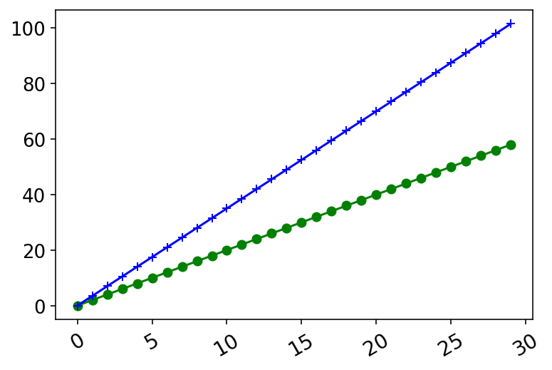

```python
x1 = np.arange(0, 30)
plt.plot(x1,x1*2,marker='o',color='g')
plt.plot(x1,x1*3.5,marker='+',color='b')
plt.tick_params(axis='x',labelsize=14,rotation=30)
plt.tick_params(axis='y',labelsize=13)
plt.show()
```

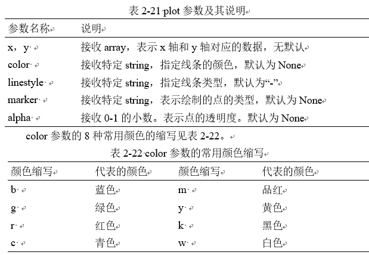

#### 散点图

散点图（Scatter Diagram）又称为散点分布图，是以一个特征为横坐标，另一个特征为纵坐标，利用坐标点（散点）的分布形态反映特征间的统计关系的一种图形。值是由点在图表中的位置表示，类别是由图表中的不同标记表示，通常用于比较跨类别的数据。

**scatter** 方法格式：

matplotlib.pyplot.scatter(x, y, s=None, c=None, marker=None, alpha=None, **kwargs)

##### 【例2-92】scatter绘图示例1。

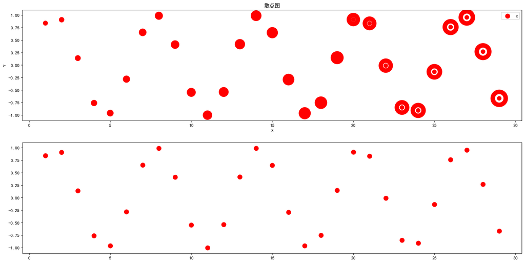

```python
fig,ax = plt.subplots(figsize=(20,10))
plt.rcParams['font.family'] = ['SimHei']
plt.rcParams['axes.unicode_minus'] = False
x1 = np.arange(1,30)
y1 = np.sin(x1)
ax1 = plt.subplot(2,1,1)
plt.title('散点图')
plt.xlabel('X')
plt.ylabel('Y')
lvalue = x1
ax1.scatter(x1,y1,c = 'r',s = 100,linewidths = lvalue,marker = 'o')
plt.legend('x1')
ax2 = plt.subplot(2,1,2)
ax2.scatter(x1,y1,c = 'r',s = 100,marker = 'o')

plt.show()
```

#### 直方图

直方图（Histogram）又称质量分布图，是统计报告图的一种，由一系列高度不等的纵向条纹或线段表示数据分布的情况，一般用横轴表示数据所属类别，纵轴表示数量或者占比。用直方图可以比较直观地看出产品质量特性的分布状态，便于判断其总体质量分布情况。直方图可以发现分布表无法发现的数据模式、样本的频率分布和总体的分布。

绘制直方图函数bar格式：

matplotlib.pyplot.bar（left，height，width = 0.8，bottom = None，hold = None，data = None，** kwargs ）

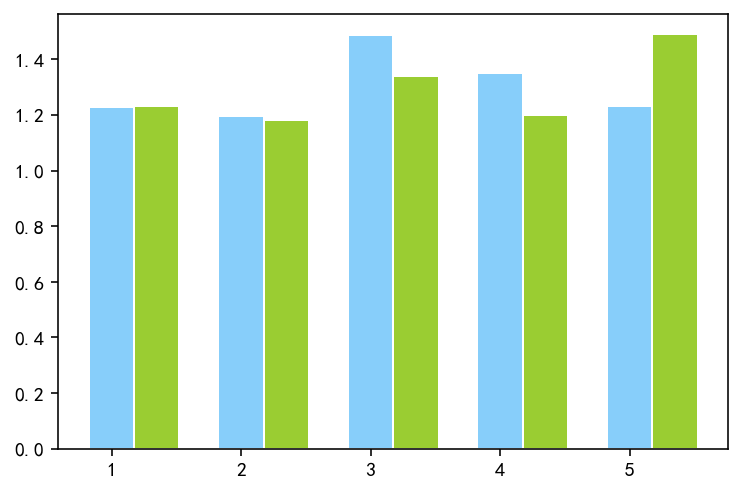

```python
fig,ax = plt.subplots()
plt.rcParams['font.family'] = ['SimHei']
plt.rcParams['axes.unicode_minus'] = False
x = np.arange(1,6)
Y1 = np.random.uniform(1.5,1.0,5)  #numpy.random.uniform(low,high,size)
Y2 = np.random.uniform(1.5,1.0,5)
plt.bar(x,Y1,width = 0.35,facecolor = 'lightskyblue',edgecolor = 'white')
plt.bar(x+0.35,Y2,width = 0.35,facecolor = 'yellowgreen',edgecolor = 'white')
plt.show()
```

#### 饼图

饼图（Pie Graph）是将各项的大小与各项总和的比例显示在一张“饼”中，以“饼”的大小来确定每一项的占比。饼图可以比较清楚地反映出部分与部分、部分与整体之间的比例关系，易于显示每组数据相对于总数的大小，而且显现方式直观。

绘制饼图pie方法格式：

matplotlib.pyplot.pie(x, explode=None, labels=None, colors=None, autopct=None, pctdistance=0.6,shadow=False,labeldistance=1.1, startangle=None, radius=None, … )

##### 【例2-94】pie绘图示例。

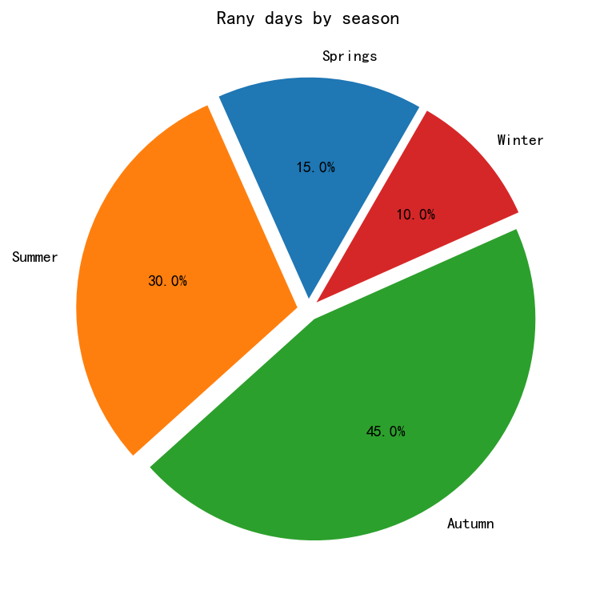

```python
plt.figure(figsize = (6,6))
ax = plt.axes([0.1,0.1,0.8,0.8])
labels = 'Springs','Summer','Autumn','Winter'
x = [15,30,45,10 ]
explode = (0.05,0.05,0.05,0.05 )
#控制分离的距离，默认饼图不分离
plt.pie(x,labels = labels,explode = explode,startangle = 60,autopct = '%1.1f%%')  #qutopct在图中显示比例值，注意值的格式

plt.title('Rany days by season')
plt.tick_params(labelsize = 12)
plt.show()
```

#### 箱线图

箱线图（Boxplot）也称箱须图，其绘制需使用常用的统计量，能提供有关数据位置和分散情况的关键信息，尤其在比较不同特征时，更可表现其分散程度差异。箱线图利用数据中的五个统计量（最小值、下四分位数、中位数、上四分位数和最大值）来描述数据，它也可以粗略地看出数据是否具有对称性、分布的分散程度等信息，特别可以用于对几个样本的比较。

**boxplot函数**格式：

matplotlib.pyplot.boxplot(x, notch=None, sym=None, vert=None, whis=None, positions=None, widths=None, patch_artist=None,meanline=None, labels=None, … )

##### 【例2-95】boxplot绘图示例。

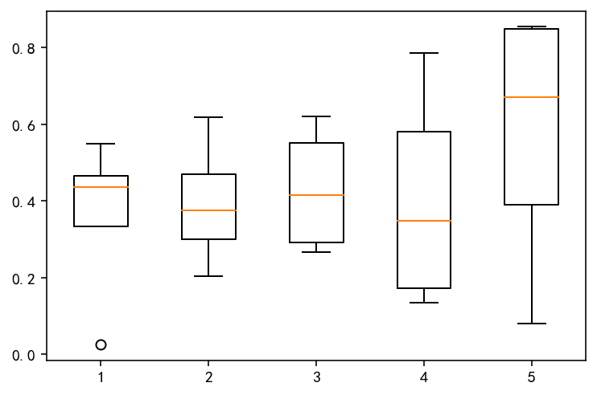

```python
import pandas as pd
np.random.seed(2)  #设置随机种子
#df = pd.DataFrame(np.random.rand(1,500)) #生成0-1之间的1*500维度数据并存入 DataFrame中
df = pd.DataFrame(np.random.rand(5,4), columns = ['A', 'B', 'C', 'D']) #生成0-1之间的5*4维度数据并存入4列DataFrame中
plt.boxplot(df)
plt.show()
```

#### 概率图

概率图模型是图灵奖获得者Pearl提出的用来表示变量间概率依赖关系的理论。  
**正态分布又名高斯分布。**

正态概率密度函数normpdf（x，mu，sigma），其中，x为向量，mu为均值，sigma为标准差。

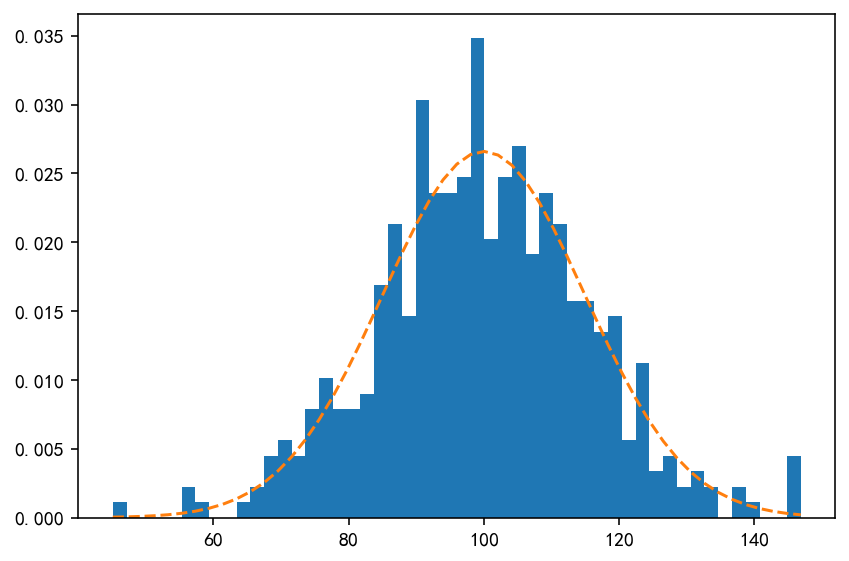

```python
from scipy.stats import norm
fig,ax = plt.subplots()
plt.rcParams['font.family'] = ['SimHei']
np.random.seed(1587554)
mu = 100  #设置均值
sigma = 15  #设置标准差
x = mu+sigma*np.random.randn(437)
num_bins = 50
n,bins,patches = ax.hist(x,num_bins,density = 1)
y=norm.pdf(bins,mu,sigma)
ax.plot(bins,y,'--')
fig.tight_layout()
plt.show()
```

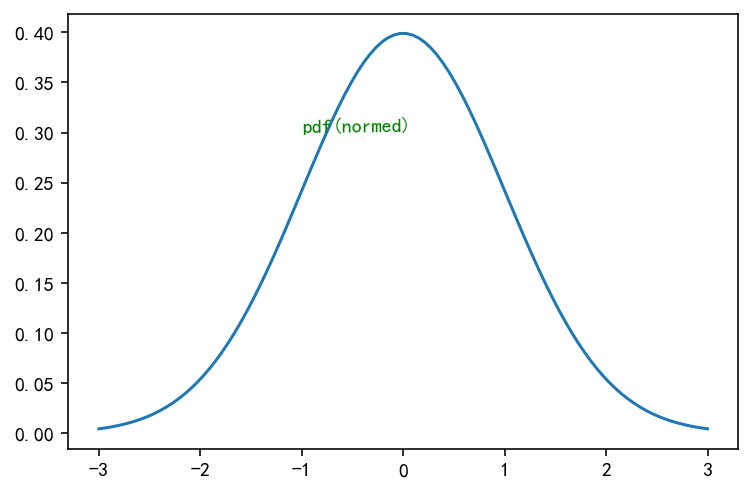

```python
import numpy as np
import matplotlib.pyplot as plt
import scipy.stats as stats

#概率密度函数
plt.plot(np.linspace(-3,3,100),stats.norm.pdf(np.linspace(-3,3,100))) #从（-3，3）中随机选取100个数，绘制该事件的概率密度函数
#plt.fill_between(np.linspace(-3,3,100),stats.norm.pdf(np.linspace(-3,3,100)),alpha=.15)#对曲线内部进行填充
#注解
plt.text(x=-1,y=0.3,s="pdf(normed)",rotation=.65,weight="bold",color='g')
```